# Paper-plots

## 14.1 Fig S3B Classic Behavior IFS animals

action required! dataframe of classic behaviors instead of US object

```r
US <- readRDS("objects/US_object_IFS_OFT1.rds")
report <- cbind(US$Report,US$meta)
```

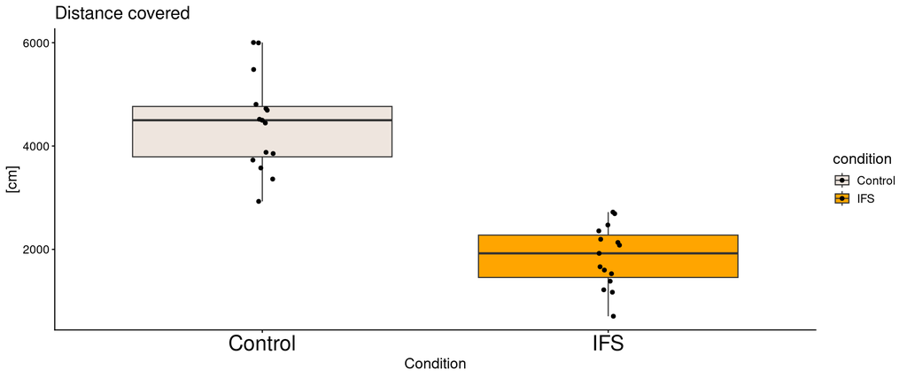

```r
e <- ggplot(report, aes(x = condition, y = raw.bodycentre.distance.moving, fill=condition))
cols <- c("seashell2", "#ffa500ff")

e2 <- e +
  geom_boxplot(width = 0.75, outlier.shape = NA) +
  geom_jitter(position = position_jitterdodge(jitter.width = 0.1), dodge.width = 0.75) +
  #stat_summary(fun = mean, geom = "point", shape = 4, size = 3, color = "red", fill = "red") +
  geom_signif(comparisons = list(c("Control", "Stress")), map_signif_level = TRUE) +
  scale_fill_manual(values = cols) +
  labs(title = "Distance covered") +
  ylab("[cm]") +
  xlab("Condition") +
  theme_classic() +
  theme(
    axis.text.x = element_text(size = 20),
    text = element_text(size = 14)
  )

print(e2)
```

```r
ggsave("plots/FigS3B_father_OFT1.Distance.png")
ggsave("plots/FigS3B_father_OFT1.Distance.pdf")
ggsave("plots/FigS3B_father_OFT1.Distance.svg")
```

```r
t.test(raw.bodycentre.center.distance.moving ~condition, data = report, alternative = "two.sided")
```

```
##
##  Welch Two Sample t-test
##
## data:  raw.bodycentre.center.distance.moving by condition
## t = 3.0991, df = 27.402, p-value = 0.004454
## alternative hypothesis: true difference in means between group Control and group IFS is not equal to 0
## 95 percent confidence interval:
##   73.99382 363.33558
## sample estimates:
## mean in group Control     mean in group IFS
##              506.2785              287.6138
```

```r
wilcox.test(raw.bodycentre.center.distance.moving ~condition, data = report, alternative = "two.sided")
```

```
##
##  Wilcoxon rank sum exact test
##
## data:  raw.bodycentre.center.distance.moving by condition
## W = 177, p-value = 0.006568
## alternative hypothesis: true location shift is not equal to 0
```

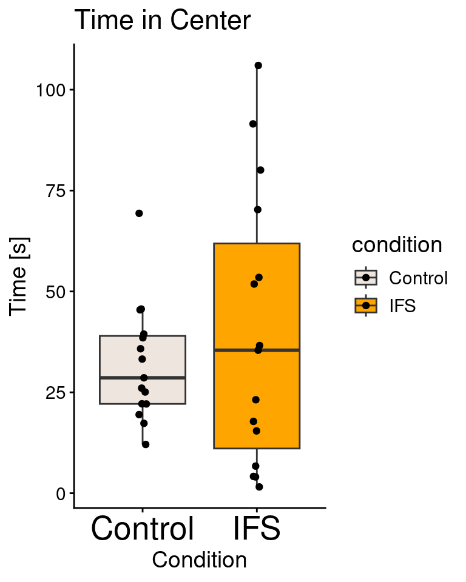

```r
e <- ggplot(report, aes(x = condition, y = raw.bodycentre.center.total.time, fill=condition))
cols <- c("seashell2", "#ffa500ff")

e2 <- e +
  geom_boxplot(width = 0.75, outlier.shape = NA) +
  geom_jitter(position = position_jitterdodge(jitter.width = 0.1), dodge.width = 0.75) +
  #stat_summary(fun = mean, geom = "point", shape = 4, size = 3, color = "red", fill = "red") +
  geom_signif(comparisons = list(c("Control", "Stress")), map_signif_level = TRUE) +
  scale_fill_manual(values = cols) +
  labs(title = "Time in Center") +
  ylab("Time [s]") +
  xlab("Condition") +
  theme_classic() +
  theme(
    axis.text.x = element_text(size = 20),
    text = element_text(size = 14)
  )

print(e2)
```

```r
ggsave("plots/FigS3B_father_OFT1.TIC.png")
ggsave("plots/FigS3B_father_OFT1.TIC.pdf")
ggsave("plots/FigS3B_father_OFT1.TIC.svg")
```

```r
t.test(raw.bodycentre.center.total.time ~condition, data = report, alternative = "two.sided")
```

```
##
##  Welch Two Sample t-test
##
## data:  raw.bodycentre.center.total.time by condition
## t = -0.81782, df = 18.847, p-value = 0.4237
## alternative hypothesis: true difference in means between group Control and group IFS is not equal to 0
## 95 percent confidence interval:
##  -27.96325  12.25658
## sample estimates:
## mean in group Control     mean in group IFS
##              32.02133              39.87467
```

```r
wilcox.test(raw.bodycentre.center.total.time ~condition, data = report, alternative = "two.sided")
```

```
##
##  Wilcoxon rank sum exact test
##
## data:  raw.bodycentre.center.total.time by condition
## W = 110, p-value = 0.9349
## alternative hypothesis: true location shift is not equal to 0
```

## 14.2 Fig S3C Motif activity analysis of GR-ChIP sperm IFS

action required (object files)

```r
df <- readRDS("objects/GRChIPArche_Results.DF.rds")
```

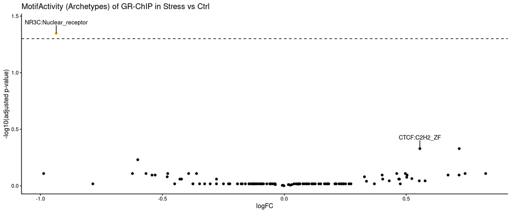

```r
library(scales)


xlim <- c(-7, 7)
ylim <- c(0,6)

# Function to generate volcano plots
generate_volcano_plot <- function(df, title) {
  df$highlight <- df$adj.P.Val < 0.05
  # df$extreme[df$logFC > xlim[2] | df$logFC < xlim[1] | -log10(df$FDR) > ylim[2] | -log10(df$FDR) < ylim[1]] <- "extreme"
  # df$highlight[df$extreme == "extreme"] <- "extreme"
  top_genes <- df[1:2,]
  ggplot(df, aes(x=logFC, y=-log10(adj.P.Val))) +
    geom_point(aes(color = highlight)) +
    scale_color_manual(values = c("TRUE" = "orange", "FALSE" = "black")) +
    geom_text_repel(data = top_genes, aes(label=archetype), size=3.5, min.segment.length = 0, max.overlaps = Inf, nudge_y = 0.1) +
    geom_hline(yintercept=-log10(0.05), linetype="dashed")+
    xlab("logFC") +
    ylab("-log10(adjusted p-value)") +
    theme_classic() +
    theme(legend.position="none") +
    ggtitle(title)
}

# Apply the function to each dataframe in the list
generate_volcano_plot(df, "MotifActivity (Archetypes) of GR-ChIP in Stress vs Ctrl")
```

```r
ggsave("plots/FigS3C_MotifAct_GRChIP_volcano.svg")
ggsave("plots/FigS3C_MotifAct_GRChIP_volcano.pdf")
ggsave("plots/FigS3C_MotifAct_GRChIP_volcano.png")
```

## 14.3 Fig S3D GO:BP overrepresentation analysis of differential expressed genes in embryos with IFS sperm donor

Results differ slightly from figure in manuscript (new package vetrsions ?)

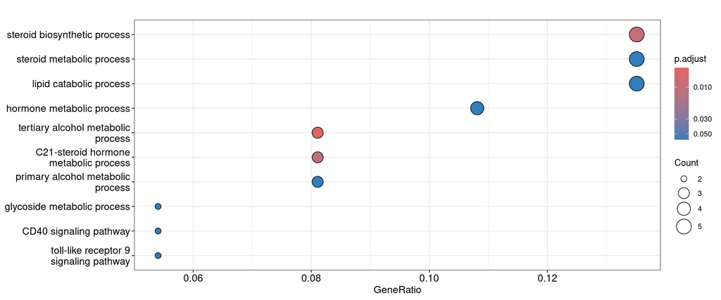

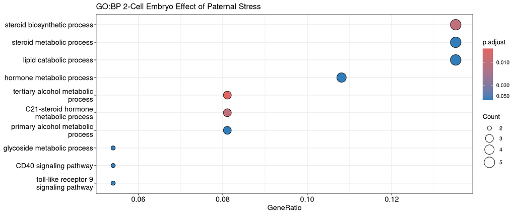

```r
set.seed(312)

dea <- Results$DMSO_IFSvsCTRL

  gene_list <- dea[dea$FDR <= 0.05,]$ID # this get us all significantly differential expressed genes
kegg <- enrichGO(gene          = gene_list,
                OrgDb         = org.Mm.eg.db,
                keyType       = "SYMBOL",
                ont           = "BP",  # BP: Biological Process, MF: Molecular Function, CC: Cellular Component
                pAdjustMethod = "BH",
                pvalueCutoff  = 1,
                qvalueCutoff  = 1,
                 universe = dea$ID
                    )




  d <- dotplot(kegg, showCategory=10)


print(d)+ggtitle("GO:BP 2-Cell Embryo Effect of Paternal Stress")
```

```r
ggsave("sup_plots/FigS3D.2cellGOBP_IFSvsCtrl_DMSO.svg")
ggsave("sup_plots/FigS3D.2cellGOBP_IFSvsCtrl_DMSO.pdf")
ggsave("sup_plots/FigS3D.2cellGOBP_IFSvsCtrl_DMSO.png")
```

# 15 Fig 4D Counteracting differential interaction genes in 2cellEmbryo from IFS-KH103 sperm fathers

```r
se <- readRDS("objects/SummarizedExperimentObject_EmbryoFromIFS_Sperm_treatedKH103.SE.rds")
Results <- getDEA(se)
```

```r
# Results$Total_PROTACvsDMSO
RNA_df_Stress_total <- Results$Total_IFSvsCTRL

RNA_df_Stress_Protac <- Results$IFS_PROTAC_int
RNA_df_Stress_Protac <- RNA_df_Stress_Protac[which(RNA_df_Stress_Protac$FDR < 0.05),]

habituation_list <- RNA_df_Stress_total[, c(1, 6)] #get the logFC and ID
colnames(habituation_list)[1] <- "Stress_coef"

habituation_list$StressProtac_coef <- RNA_df_Stress_Protac[rownames(RNA_df_Stress_total[rownames(RNA_df_Stress_total),]),]$logFC
habituation_list1 <- habituation_list[which(habituation_list$StressProtac_coef * habituation_list$Stress_coef < 0),]
```

```r
metadata(se)$anno_colors <- list(condition=c(CTRL="steelblue", IFS ="firebrick3"), treatment =c(PROTAC = "orange", DMSO = "purple4"), Group = c("DMSO.CTRL" = "seashell2","DMSO.IFS" =  "#ffa500ff" , "PROTAC.CTRL" = "seashell4" , "PROTAC.IFS" = "tomato3"))
```

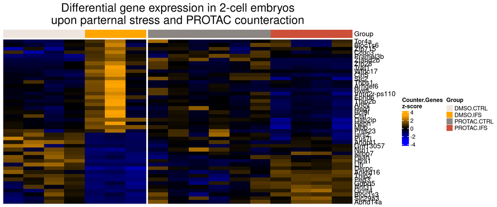

```r
color_palette <- colorRampPalette(c("blue", "black", "orange"))(101)
rownames(se) <- gsub(x = rownames(se),pattern = "^ENS(.*)\\.",replacement = "")



sh <- sechm(se,features = habituation_list1$ID,assayName = "corrected",hmcols = color_palette,do.scale =T,gaps_at = c("treatment"),column_order = colnames(se)[order(colData(se)$condition)],show_rownames = T,name = paste0("Counter.Genes","\nz-score"),top_annotation = c("Group"),use_raster = T,column_title = "Differential gene expression in 2-cell embryos\nupon parternal stress and PROTAC counteraction",column_title_gp = gpar(fontsize = 20))
print(sh)
```

```r
pdf("plots/Fig4D.counteractingProtacGenes.heatmap.pdf", width=14.5, height=10) #, width=14.5, height=10)

print(sh)
dev.off()
```

```r
png("plots/Fig4D.counteractingProtacGenes.heatmap.png", height=638,width = 872,)

print(sh)
dev.off()
```

```r
svg("plots/Fig4D.counteractingProtacGenes.heatmap.svg") #, width=14.5, height=10)

print(sh)
dev.off()
```

# 16 Fig 4E Offspring HC differential interacting sex:stress genes of IFS-KH103 sperm fathers

```r
se <- readRDS("objects/se_HPP_offspring_with_DEA_result.rds")
results_DMSO_stressSex_int <-rowData(se)$DEA.DMSO_interaction_between_sex_n_stress
table(results_DMSO_stressSex_int$FDR < 0.05)
```

```
##
## FALSE  TRUE
## 14156   693
```

```r
sig_results_DMSO_stressSex_int <- results_DMSO_stressSex_int[results_DMSO_stressSex_int$FDR < 0.05,]
```

```r
metadata(se)$anno_colors <- list(stress=c(CTRL="steelblue", IFS ="firebrick3"), sex =c(m = "forestgreen", f = "purple4"), condition = c("ctrl_DMSO" = "seashell2","stress_DMSO" =  "#ffa500ff" , "ctrl_PROTAC" = "seashell4" , "stress_PROTAC" = "tomato3"))
```

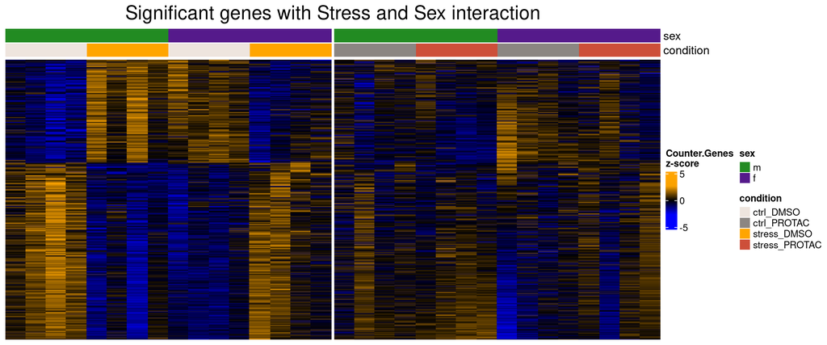

```r
color_palette <- colorRampPalette(c("blue", "black", "orange"))(101)
rownames(se) <- gsub(x = rownames(se),pattern = "^ENS(.*)\\.",replacement = "")



sh <- sechm(se,features = rownames(sig_results_DMSO_stressSex_int),assayName = "corrected",hmcols = color_palette,do.scale =T,gaps_at = c("protac"),column_order = colnames(se)[order(colData(se)$sex)],show_rownames = F,name = paste0("Counter.Genes","\nz-score"),top_annotation = c("sex","condition"),use_raster = T,column_title_gp = gpar(fontsize = 20),,column_title = "Significant genes with Stress and Sex interaction")
print(sh) #
```

```r
pdf("plots/Fig4E_SexStressInt.pdf", width=14.5, height=10) #, width=14.5, height=10)

print(sh)
dev.off()
```

```r
png("plots/Fig4E_SexStressInt.png", height=638,width = 872,)

print(sh)
dev.off()
```

```r
svg("plots/Fig4E_SexStressInt.svg") #, width=14.5, height=10)

print(sh)
dev.off()
```

# 17 Fig 4F Cort Response of IFS offspring

action required! df should be corrected for timepoint 120

```r
df <- read.csv("objects/CortOffspring.csv")
df$Group3 <- interaction(df$stress,df$treatment)
```

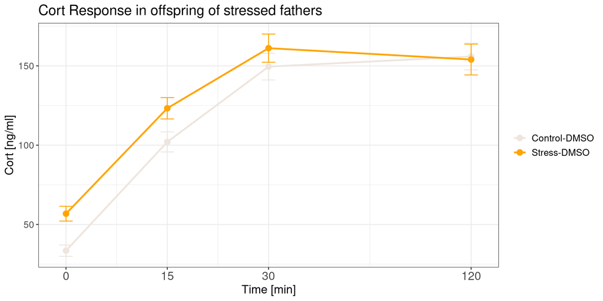

```r
df3 <- df[df$treatment == "DMSO",]

df3$x_pos <- as.numeric(as.character(df3$time))

df3$x_pos[df3$time == "180"] <- 60




library(ggplot2)

gg <- ggplot(df3, aes(x = x_pos,
               y = corticosterone,
               color = Group3,
               group = Group3)) +

  # mean line
  stat_summary(fun = mean,
               geom = "line",
               size = 1) +

  # points at each timepoint (mean)
  stat_summary(fun = mean,
               geom = "point",
               size = 3) +

  # error bars: mean ± SEM
  stat_summary(
    fun.data = mean_se,   # mean ± standard error
    geom = "errorbar",
    width = 2,
    # linewidth = 0.8
  ) +
    scale_color_manual(values=c( "seashell2","#ffa500ff","seashell4","tomato3"),labels = c("Control-DMSO","Stress-DMSO","Control-KH-103","Stress-KH-103"))+ #  scale_color_manual(values=c( "seashell2","#ffa500ff","seashell4","tomato3"))+

 scale_x_continuous(
    breaks = c(0, 15, 30, 60),
    labels = c("0", "15", "30", "120")
  ) +

 labs(color= NULL)+
  theme_bw() +
   theme(
  axis.text.x = element_text(size = 14),
  text = element_text(size = 14),
)+

  labs(
    x = "Time [min]",
    y = "Cort [ng/ml]",
    title = "Cort Response in offspring of stressed fathers"
   )

print(gg)
```

```r
 ggsave("plots/Fig4F_CortResponse.svg")
 ggsave("plots/Fig4F_CortResponse.png")
 ggsave("plots/Fig4F_CortResponse.pdf")
```

# 18 Fig 4G Cort Response of IFS KH103 sperm offspring

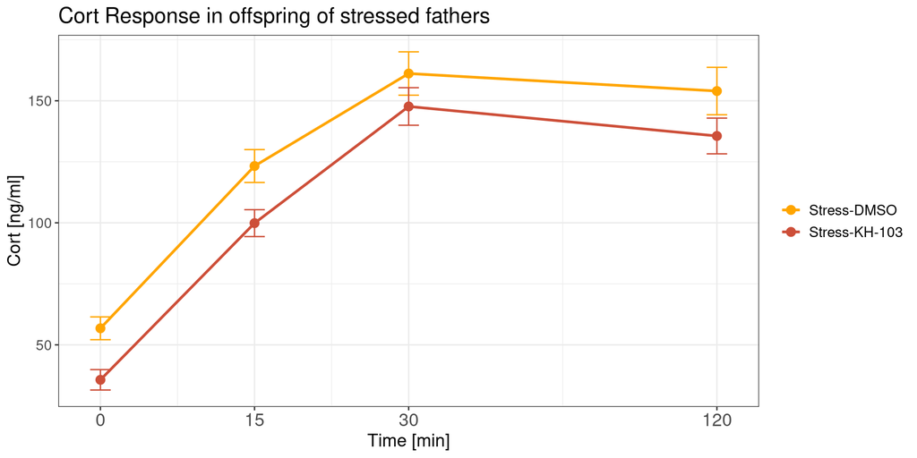

```r
df3 <- df[df$stress == "stressed",]

df3$x_pos <- as.numeric(as.character(df3$time))

df3$x_pos[df3$time == "180"] <- 60




library(ggplot2)

gg <- ggplot(df3, aes(x = x_pos,
               y = corticosterone,
               color = Group3,
               group = Group3)) +

  # mean line
  stat_summary(fun = mean,
               geom = "line",
               size = 1) +

  # points at each timepoint (mean)
  stat_summary(fun = mean,
               geom = "point",
               size = 3) +

  # error bars: mean ± SEM
  stat_summary(
    fun.data = mean_se,   # mean ± standard error
    geom = "errorbar",
    width = 2,
    # linewidth = 0.8
  ) +
    #scale_color_manual(values=c( "seashell2","#ffa500ff","seashell4","tomato3"),labels = c("Control-DMSO","Stress-DMSO","Control-KH-103","Stress-KH-103"))+
    scale_color_manual(values=c( "#ffa500ff","tomato3"),labels = c("Stress-DMSO","Stress-KH-103"))+

 scale_x_continuous(
    breaks = c(0, 15, 30, 60),
    labels = c("0", "15", "30", "120")
  ) +

 labs(color= NULL)+
  theme_bw() +
   theme(
  axis.text.x = element_text(size = 14),
  text = element_text(size = 14),
)+

  labs(
    x = "Time [min]",
    y = "Cort [ng/ml]",
    title = "Cort Response in offspring of stressed fathers"
   )

print(gg)
```

```r
 ggsave("plots/Fig4G_KH103_CortResponse.svg")
 ggsave("plots/Fig4G_KH103_CortResponse.png")
 ggsave("plots/Fig4G_KH103_CortResponse.pdf")
```